# exercise-10

SLCornett

5-8 April 2022

# *Exercise 10: Week 11 Programming Exercise - Check Assumptions of Regression*

Preliminaries

```r
library(tidyverse) # always necessary for so many things (reqd_cvs, etc.)
```

```r
library(tidyr) # drop_na()
library(dplyr) # for %>% and mutate()
library(ggplot2) # for ggplot
library(car) # for qqPlot
```

1. Using the {tidyverse} read_csv() function, load the “KamilarAndCooperData.csv” dataset from this URL as a “tibble” named **d**.

```r
f <- "https://raw.githubusercontent.com/difiore/ada-2022-datasets/main/KamilarAndCooperData.csv"
d <- read_csv(f, col_names = TRUE)
print(d)
```

```
## # A tibble: 213 × 44
##    Scientific_Name        Family Genus Species Brain_Size_Spec… Brain_Size_Fema…
##    <chr>                  <chr>  <chr> <chr>              <dbl>            <dbl>
##  1 Allenopithecus_nigrov… Cerco… Alle… nigrov…             58.0             53.7
##  2 Allocebus_trichotis    Cerco… Allo… tricho…             NA               NA
##  3 Alouatta_belzebul      Ateli… Alou… belzeb…             52.8             51.2
##  4 Alouatta_caraya        Ateli… Alou… caraya              52.6             47.8
##  5 Alouatta_guariba       Ateli… Alou… guariba             51.7             49.1
##  6 Alouatta_palliata      Ateli… Alou… pallia…             49.9             48.0
##  7 Alouatta_pigra         Ateli… Alou… pigra               51.1             48.8
##  8 Alouatta_seniculus     Ateli… Alou… senicu…             55.2             54.3
##  9 Aotus_azarai           Cebid… Aotus azarai              20.7             20.7
## 10 Aotus_brumbacki        Cebid… Aotus brumba…             NA               NA
## # … with 203 more rows, and 38 more variables: Brain_size_Ref <chr>,
## #   Body_mass_male_mean <dbl>, Body_mass_female_mean <dbl>,
## #   Mass_Dimorphism <dbl>, Mass_Ref <chr>, MeanGroupSize <dbl>,
## #   AdultMales <dbl>, AdultFemale <dbl>, AdultSexRatio <dbl>,
## #   Social_Organization_Ref <chr>, InterbirthInterval_d <dbl>, Gestation <dbl>,
## #   WeaningAge_d <dbl>, MaxLongevity_m <dbl>, LitterSz <dbl>,
## #   Life_History_Ref <chr>, GR_MidRangeLat_dd <dbl>, Precip_Mean_mm <dbl>, …
```

2. From this dataset, plot lifespan (**MaxLongevity_m**) versus female body mass (**Body_mass_female_mean**).

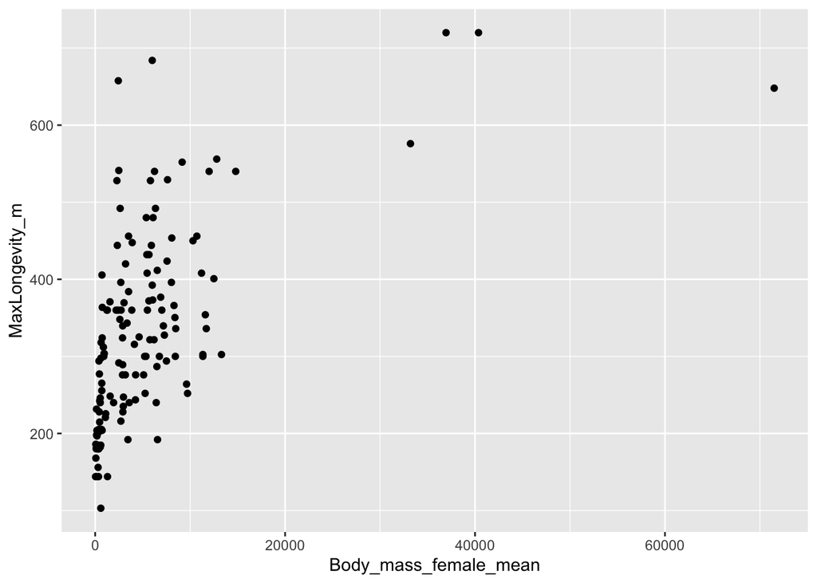

```r
# filter out all the NA from the columns -> not necessary but gets rid of the warming message from ggplot ("Removed 72 rows containing missing values (geom_point)")
df <- d %>% # pinned and exclamation mark before is "not", only matters for this part, so making a different dataframe, so it won't affect the linear models where don't need to drop the NAs
  drop_na(Body_mass_female_mean, MaxLongevity_m) # drop_na Drops rows containing missing values, {tidyr}

# plot F body mass vs lifespan
# plot 1
# plot(d$Body_mass_female_mean, d$MaxLongevity_m) #no linear relationship
p1 <- ggplot(data = df, aes(x = Body_mass_female_mean, y = MaxLongevity_m))
p1 <- p1 + geom_point()
p1 #no linear relationship
```

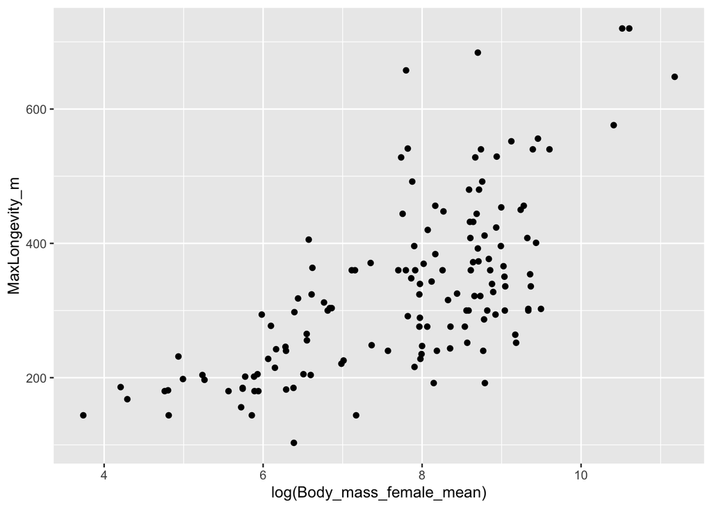

```r
#plot 2
# plot(log(d$Body_mass_female_mean), d$MaxLongevity_m) # more linear relationship
p2 <- ggplot(data = df, aes(x = log(Body_mass_female_mean), y = MaxLongevity_m))
p2 <- p2 + geom_point()
p2 # missing values (NA) # more linear relationship
```

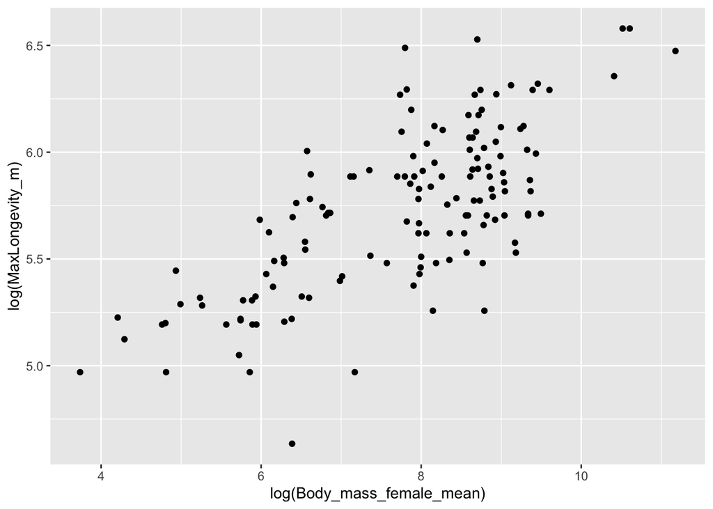

```r
# plot 3
# plot(log(d$Body_mass_female_mean), log(d$MaxLongevity_m)) # more linear relationship
p3 <- ggplot(data = df, aes(x = log(Body_mass_female_mean), y = log(MaxLongevity_m)))
p3 <- p3 + geom_point()
p3
```

**Q1:** Is the relationship linear? A1: plot 2 and 3 have relatively linear relationships, but not plot 1. **Q2:** If not, how might you transform one or both variable to more closely approximate a linear relationship? A2: log transformations seem to help, as seen in plots 2 and 3.

3. Run linear models of the comparisons of the following: **Lifespan ~ female body mass** (model 1), **lifespan ~ log(female body mass)** (model 2), and **log(lifespan) ~ log(female body mass)** (model 3).

```r
# lifespan body mass = lsbm
# using d because don't need to drop_na in linear models.
# model 1: linear model of lifespan vs. Female body mass
lsbm_m1 <- lm(data = d, MaxLongevity_m ~ Body_mass_female_mean) #creating linear model
lsbm_m1
```

```
##
## Call:
## lm(formula = MaxLongevity_m ~ Body_mass_female_mean, data = d)
##
## Coefficients:
##           (Intercept)  Body_mass_female_mean
##             283.47213                0.00905
```

```r
# model 2: linear model of lifespan vs. log(Female body mass)
lsbm_m2 <- lm(data = d, MaxLongevity_m ~ log(Body_mass_female_mean)) # creating linear model
lsbm_m2
```

```
##
## Call:
## lm(formula = MaxLongevity_m ~ log(Body_mass_female_mean), data = d)
##
## Coefficients:
##                (Intercept)  log(Body_mass_female_mean)
##                    -128.86                       59.34
```

```r
# model 3: linear model of log(lifespan0 vs. log(Female body mass)
lsbm_m3 <- lm(data = d, log(MaxLongevity_m) ~ log(Body_mass_female_mean))
lsbm_m3
```

```
##
## Call:
## lm(formula = log(MaxLongevity_m) ~ log(Body_mass_female_mean),
##     data = d)
##
## Coefficients:
##                (Intercept)  log(Body_mass_female_mean)
##                      4.259                       0.190
```

4. [A] Generate residuals for all three linear models,

```r
# A
#Residuals for model 1
lsbm_m1_resid <- lsbm_m1$residuals
lsbm_m1_resid #print it out
```

```
##            1            4            6            7            8            9
##  -36.2507584  -78.2436336  -31.8890029 -101.6628758  -30.6220194   65.3965120
##           11           14           15           16           17           18
##  115.6472465   11.6816121  -24.5889506 -130.2413968  -24.2549539  185.6309456
##           19           20           24           25           26           27
##  -21.8457745   97.0953173  151.0611148   14.4642063  -91.9973137    8.3015242
##           29           32           33           36           37           39
##   11.4761798  -72.9074777  -85.1300904 -106.9110880  -84.7861949 -101.4929811
##           40           41           42           43           44           46
## -103.3762184  223.8036368  235.2018053  352.0778291  184.6968122   37.3055336
##           47           48           49           51           52           53
##  -79.0745135   26.7535147  -17.9814029   29.8741587   88.0931851  -33.5357937
##           54           56           57           58           59           60
##  128.8333264   29.3202628 -122.6942266   -0.1549879   51.7945390   -5.2481466
##           61           62           63           67           68           69
##  -46.0246313  -81.8814992  -20.5167914 -106.7481902  -53.1300664  -75.0597843
##           70           73           74           75           78           79
##   58.6252750   71.6202584  -57.3969292    7.4138444  -14.4063396  -55.4963675
##           83           84           85           86           87           90
##  -72.4460056  139.4117769   54.5366533   64.9304431  -61.0289044 -105.8341521
##           92           93           94           97           99          101
##  -86.8042755  -81.1735107 -116.1336792 -282.5387152  -84.3355539 -151.2369797
##          102          103          104          105          106          107
##  191.8575524  106.9525642  147.8313557  199.9661030  346.1353598   99.2965077
##          109          110          111          113          116          120
##   12.9976937   56.5276274  -34.2070504    8.7160376 -185.8477629   54.5380748
##          121          123          124          125          127          128
##  -13.9994547  -88.4187601   -9.0911439   30.8836795  140.6912864   39.8573126
##          130          131          132          133          134          135
##   97.2105098   68.9488771   75.0250112   40.9981733   41.6342361  141.3235854
##          136          137          139          140          141          143
##  107.5682439 -106.5772496    4.2043388  156.6493741  -98.0802849 -139.8522278
##          144          145          146          147          151          152
##   73.2100509 -102.6956961 -119.5238673  176.7677643   28.8626409  -81.6748885
##          153          154          155          156          157          158
##  -67.9175021  -86.1147464   -7.9282242   71.2139845 -101.4355670  147.9292800
##          159          160          161          162          169          171
##   73.3140798  122.5896096   20.6734744 -142.6395916  -49.3709468  102.1564370
##          173          179          180          181          184          185
## -150.8990897  -75.9612101  -63.2407820  -59.8531392  -34.4507671  -59.3635822
##          186          187          188          189          190          191
##    6.9386839  -42.3083899  -45.3708269 -105.9500193 -104.0206132  -48.3409694
##          193          195          197          198          199          200
##  -10.3002354   73.3404555   33.8083296  -86.0977977   75.6036281 -140.5852683
##          202          203          205          207          208          209
## -104.5309690  -53.3557554   34.8882956   23.1691858  -44.6927764   -8.8683873
##          210          211          213
##  -83.6977977  -53.6536820   68.6722816
```

```r
#residuals for model 2
lsbm_m2_resid <- lsbm_m2$residuals
lsbm_m2_resid
```

```
##           1           4           6           7           8           9
##  -73.700520 -123.171617  -80.570177 -151.481524  -78.996672   66.664730
##          11          14          15          16          17          18
##  144.364761   26.645148    5.483911  -54.782185  -71.933855  139.519681
##          19          20          24          25          26          27
##  -71.330434   48.637644  101.261399  -19.820452 -124.210099   24.610636
##          29          32          33          36          37          39
##   25.219132  -21.194817  -18.826082  -43.634439  -12.206541  -27.077372
##          40          41          42          43          44          46
##   24.984882  197.782594  206.035442  323.702866  153.493606  -11.912649
##          47          48          49          51          52          53
## -127.563440  -22.211023  -67.720044   -4.651570   56.009274  -67.820452
##          54          56          57          58          59          60
##   85.788431   -9.767776 -162.536329  -46.767532   19.288402  -49.611810
##          61          62          63          67          68          69
##  -91.050866 -116.602359  -55.031112  -40.754838   67.643789 -110.246311
##          70          73          74          75          78          79
##   22.590714   22.433065 -106.659953  -40.629935  -43.586010 -105.324037
##          83          84          85          86          87          90
##  -64.817898  112.671048   26.261382   64.230769  -80.375021  -21.343263
##          92          93          94          97          99         101
##   30.642514   22.124961   42.178472  113.584502  -52.086621 -152.619753
##         102         103         104         105         106         107
##  142.433163   57.422233   99.088078  150.203326  296.523929   50.439881
##         109         110         111         113         116         120
##  -36.690917   31.892688   -4.285875   47.059580 -147.142162    4.926891
##         121         123         124         125         127         128
##  -63.351908   13.367387  -56.940604  -18.867786  100.307132   -8.667497
##         130         131         132         133         134         135
##   47.977369   19.119171   26.113536   10.248790   -1.133668   91.644858
##         136         137         139         140         141         143
##   69.927440 -151.418707  -30.128131  123.624527   65.172249   51.062334
##         144         145         146         147         151         152
##   63.361259  -28.334457 -164.060109  127.642411   64.744198  -17.806495
##         153         154         155         156         157         158
##  -61.643758  -58.700301   87.107153  219.508805 -132.209320  111.494252
##         159         160         161         162         169         171
##   30.559217   99.049405   39.356221  -74.754418  -59.794677  224.760675
##         173         179         180         181         184         185
## -200.728952 -116.896760  -98.645909 -107.622505  -72.494024   -2.969710
##         186         187         188         189         190         191
##   67.828356    2.132150    5.524189  -61.976451  -65.041705   -4.266256
##         193         195         197         198         199         200
##   44.182238   99.620078   60.616466 -125.148855   34.242934  -12.699530
##         202         203         205         207         208         209
##   26.268096  -91.003385  -14.761808  -16.411700  -94.493520  -58.444743
##         210         211         213
## -122.748855 -101.765290   28.271720
```

```r
#residuals for model 3
lsbm_m3_resid <- lsbm_m3$residuals
lsbm_m3_resid
```

```
##             1             4             6             7             8
## -0.1704830792 -0.3500029811 -0.1859188423 -0.4439908863 -0.1808818686
##             9            11            14            15            16
##  0.2756518269  0.4976711911  0.1576944697  0.0776509750 -0.2963341423
##            17            18            19            20            24
## -0.1601844825  0.3216986427 -0.1566812871  0.1494322265  0.2762270880
##            25            26            27            29            32
##  0.0086823571 -0.3852255897  0.1507772084  0.1531296256 -0.0571913618
##            33            36            37            39            40
## -0.0707758536 -0.1943748637 -0.0495859306 -0.1304218110  0.0280867917
##            41            42            43            44            46
##  0.5405800593  0.5494362630  0.7483013807  0.4434284758  0.0184928940
##            47            48            49            51            52
## -0.3570495459 -0.0088498249 -0.1444021243  0.0543272345  0.2216124503
##            53            54            56            57            58
## -0.1516602929  0.2742471520  0.0369705573 -0.5488685607 -0.0777228685
##            59            60            61            62            63
##  0.1239946750 -0.0860618040 -0.2260235576 -0.3452185051 -0.1062572393
##            67            68            69            70            73
## -0.1851569225  0.2487169998 -0.3168295075  0.1301523518  0.0931556715
##            74            75            78            79            83
## -0.2704312664 -0.0704883067 -0.0690383039 -0.2679014621 -0.1884906826
##            84            85            86            87            90
##  0.3637501521  0.1463159995  0.2678604350 -0.2163706783 -0.1230182066
##            92            93            94            97            99
##  0.0810844074  0.0644649907  0.0497428024  0.0917125623 -0.1710711590
##           101           102           103           104           105
## -0.6511529177  0.3634000750  0.1868922493  0.2829908214  0.3723327289
##           106           107           109           110           111
##  0.6161500288  0.1755553514 -0.0552016536  0.1643424649  0.0402369346
##           113           116           120           121           123
##  0.2222894068 -0.8374570392  0.0604833206 -0.1304192110  0.0235470066
##           124           125           127           128           130
## -0.1163212152 -0.0063159796  0.3124266610  0.0145745618  0.1676725649
##           131           132           133           134           135
##  0.0922233005  0.1173522709  0.0995696729  0.0586212462  0.2591642053
##           136           137           139           140           141
##  0.2481798237 -0.4253064223 -0.0574404505  0.2652882824  0.1675111601
##           143           144           145           146           147
##  0.0008572012  0.2600637732 -0.1371192287 -0.4738796407  0.3144819606
##           151           152           153           154           155
##  0.2798982306 -0.0613364795 -0.1721890422 -0.1942660991  0.1196528414
##           156           157           158           159           160
##  0.3056687306 -0.3509362722  0.2484204705  0.0951169224  0.2085830624
##           161           162           169           171           173
##  0.1987868600 -0.4018968988 -0.1429785487  0.3224805786 -0.6711276008
##           179           180           181           184           185
## -0.3332810234 -0.2683471593 -0.2725164991 -0.1674119956  0.0185328580
##           186           187           188           189           190
##  0.2881261651  0.0532303150  0.0608703653 -0.2475272356 -0.2519500700
##           191           193           195           197           198
##  0.0272623581  0.2073704428  0.3795720517  0.2661703141 -0.3286203882
##           199           200           202           203           205
##  0.1009474580 -0.2032519619  0.0293913057 -0.2212282716  0.0087516810
##           207           208           209           210           211
## -0.0187759720 -0.2304890876 -0.1178709867 -0.3206522186 -0.2603216786
##           213
##  0.1404630450
```

[B] plot them by hand in relation to the corresponding explanatory variable,

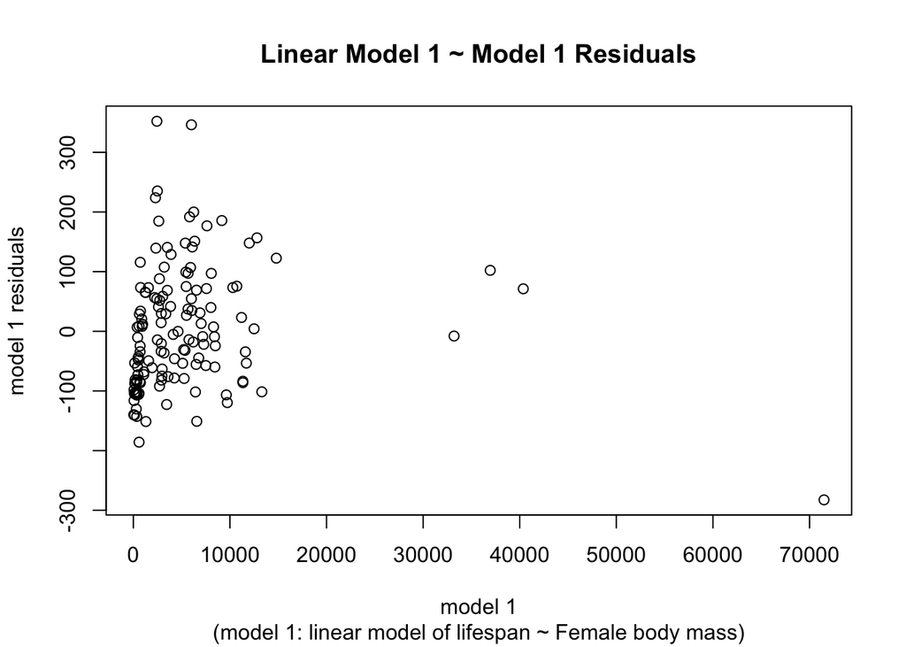

```r
# B
# body mass = explanatory variable
# model 1 vs model 1 residuals
plot(lsbm_m1$model$Body_mass_female_mean, lsbm_m1_resid,
     main = "Linear Model 1 ~ Model 1 Residuals",  #main title
     sub = "(model 1: linear model of lifespan ~ Female body mass)", # subtitle
     xlab = "model 1", # x-axis label
     ylab = "model 1 residuals") # y-axis label
```

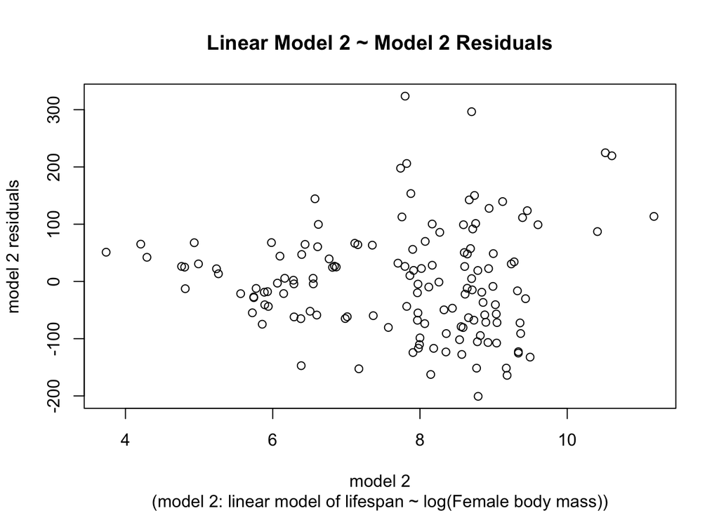

```r
# model 2 vs model 2 residual
plot(lsbm_m2$model$`log(Body_mass_female_mean)`, lsbm_m2_resid,
     main = "Linear Model 2 ~ Model 2 Residuals",  #main title
     sub = "(model 2: linear model of lifespan ~ log(Female body mass))",
     xlab = "model 2",
     ylab = "model 2 residuals")
```

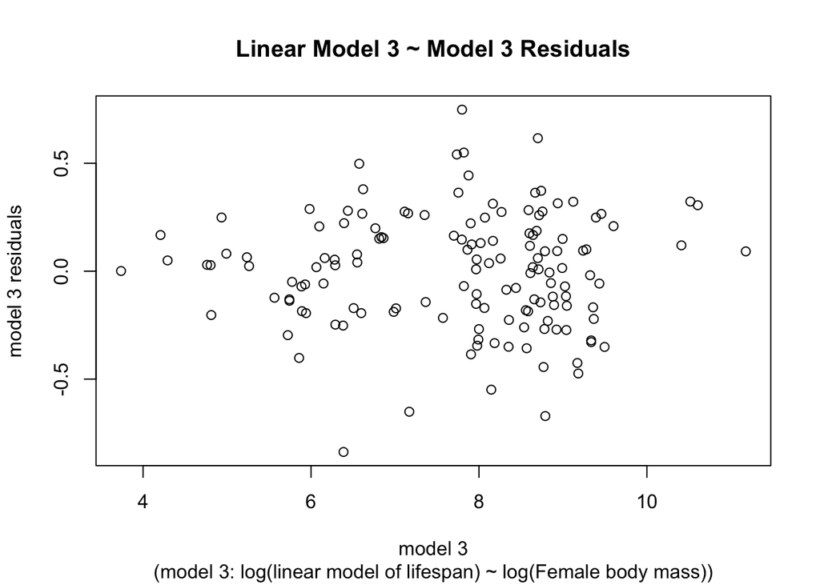

```r
# model 3 vs model 2 residual
plot(lsbm_m3$model$`log(Body_mass_female_mean)`, lsbm_m3_resid,
     main = "Linear Model 3 ~ Model 3 Residuals",
     sub = "(model 3: log(linear model of lifespan) ~ log(Female body mass))",
     xlab = "model 3",
     ylab = "model 3 residuals")
```

then [C] make histograms of the residuals.

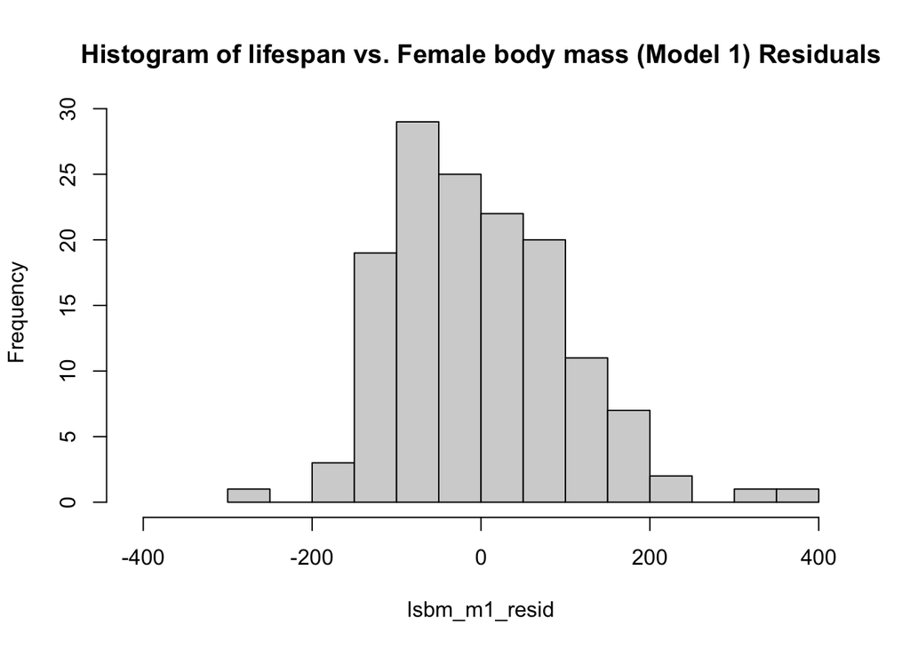

```r
# C
# model 1 residuals
hist(lsbm_m1_resid, xlim = c(-4 * sd(lsbm_m1_resid), 4 * sd(lsbm_m1_resid)), breaks = 20, main = "Histogram of lifespan vs. Female body mass (Model 1) Residuals")
```

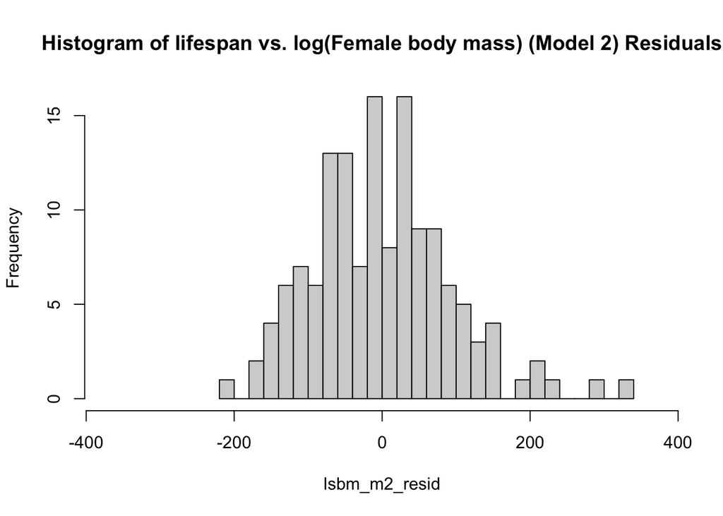

```r
# model 2 residuals
hist(lsbm_m2_resid, xlim = c(-4 * sd(lsbm_m2_resid), 4 * sd(lsbm_m2_resid)), breaks = 20, main = "Histogram of lifespan vs. log(Female body mass) (Model 2) Residuals")
```

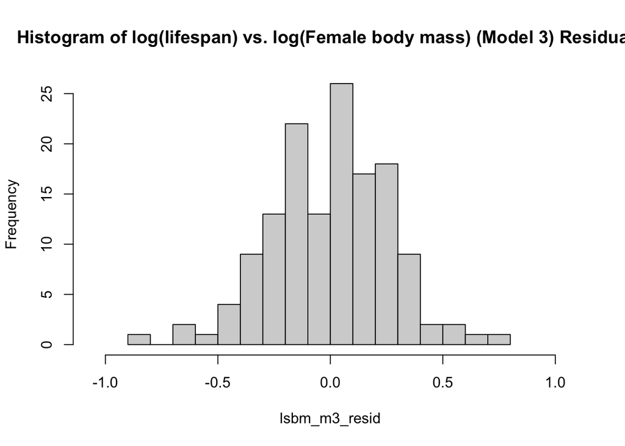

```r
# model 3 residuals
hist(lsbm_m3_resid, xlim = c(-4 * sd(lsbm_m3_resid), 4 * sd(lsbm_m3_resid)), breaks = 20, main = "Histogram of log(lifespan) vs. log(Female body mass) (Model 3) Residuals")
```

**Q:** Do they appear normally distributed? A: They appear relatively normally distributed, but they could be more normally distributed.

5. Generate QQ plots for all three linear models. [From the module: *qqPlot()* provides a trend line and confidence intervals that allow us to see exactly which points make the sample fall outside of normality (if any)]

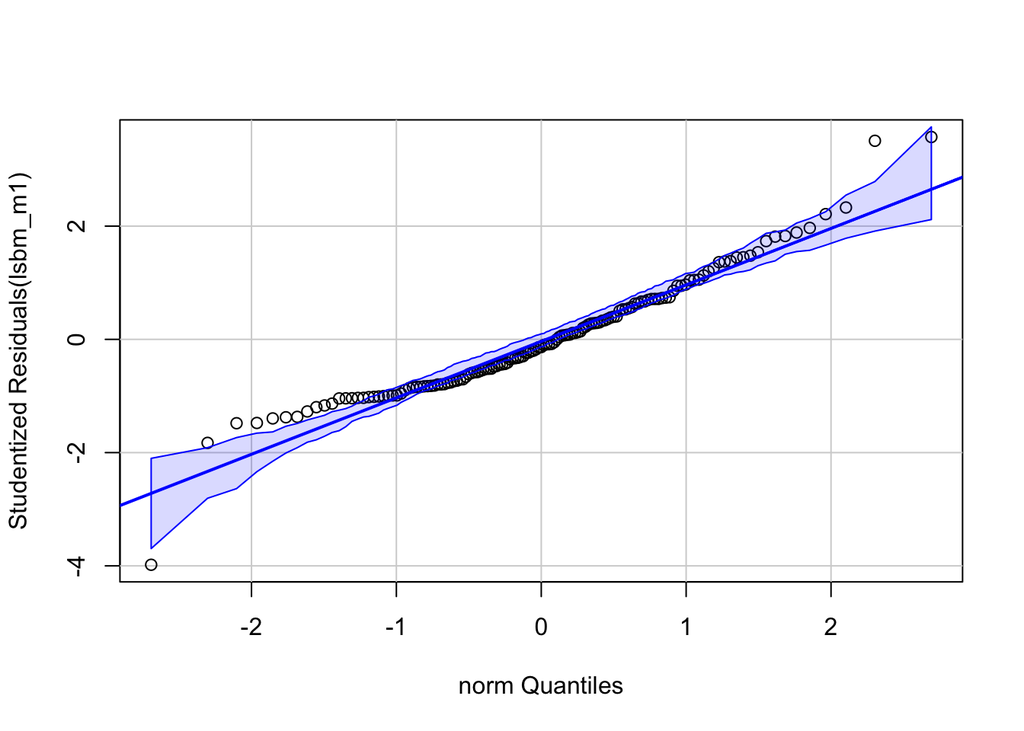

```r
# qqPlot from {car}, id=FALSE` means that outlier observations will not be labelled
# model 1
qqPlot(lsbm_m1, distribution = "norm", id = FALSE)
```

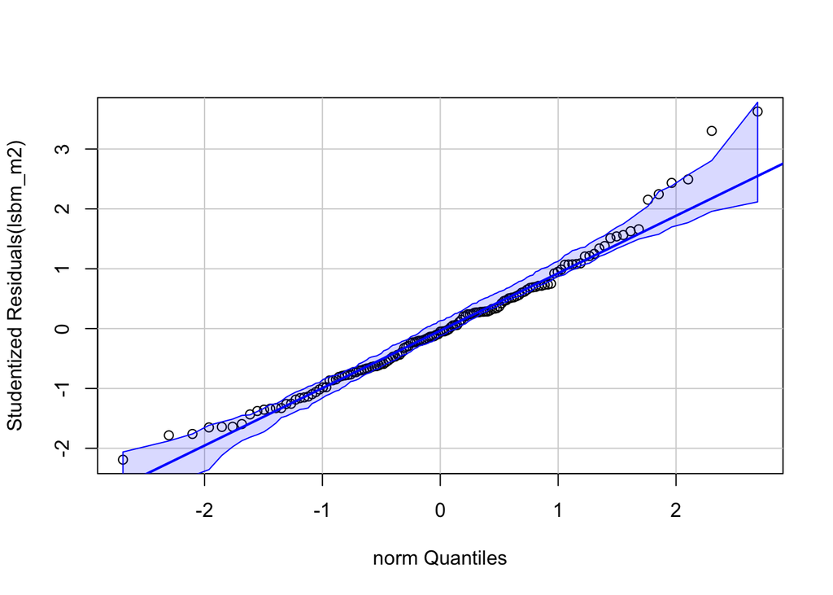

```r
# model 2
qqPlot(lsbm_m2, distribution = "norm", id = FALSE)
```

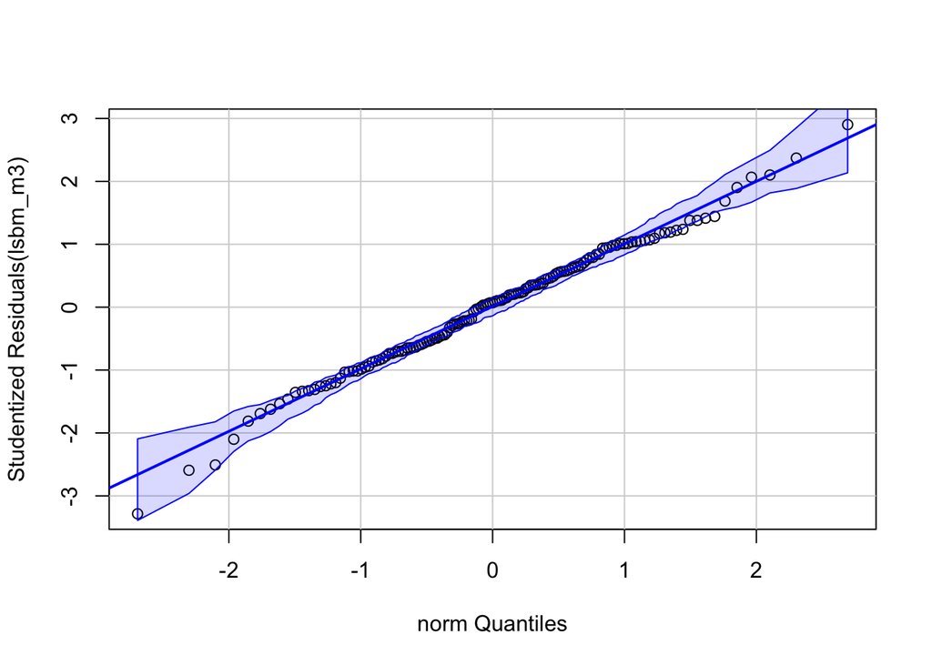

```r
# model 3
qqPlot(lsbm_m3, distribution = "norm", id = FALSE)
```

**Q1:** Do they appear to be normally distributed? Yes, they all 3 appear mostly normally distributed, as the data points are mostly within the normal distrubution range (blue). This is especially true for model 3 and to a lesser degree model 2, but least true for model 1. **Q2**: Based on visual inspection of the QQ plots, do the residual appear to deviate from being normally distributed? in the qqPlot of model 1, yes, there are residuals that appear to deviate from being normally distributed. The is also seen to a lesser extend in the qqPlot of model 2. This is not seen in model 3.

6. Run the **plot()** command on all three models. [From module 19.5: *An additional way to quickly examine your residuals is to use the plot() function with your model as an argument. This prints out four plots that each tell you something.*]

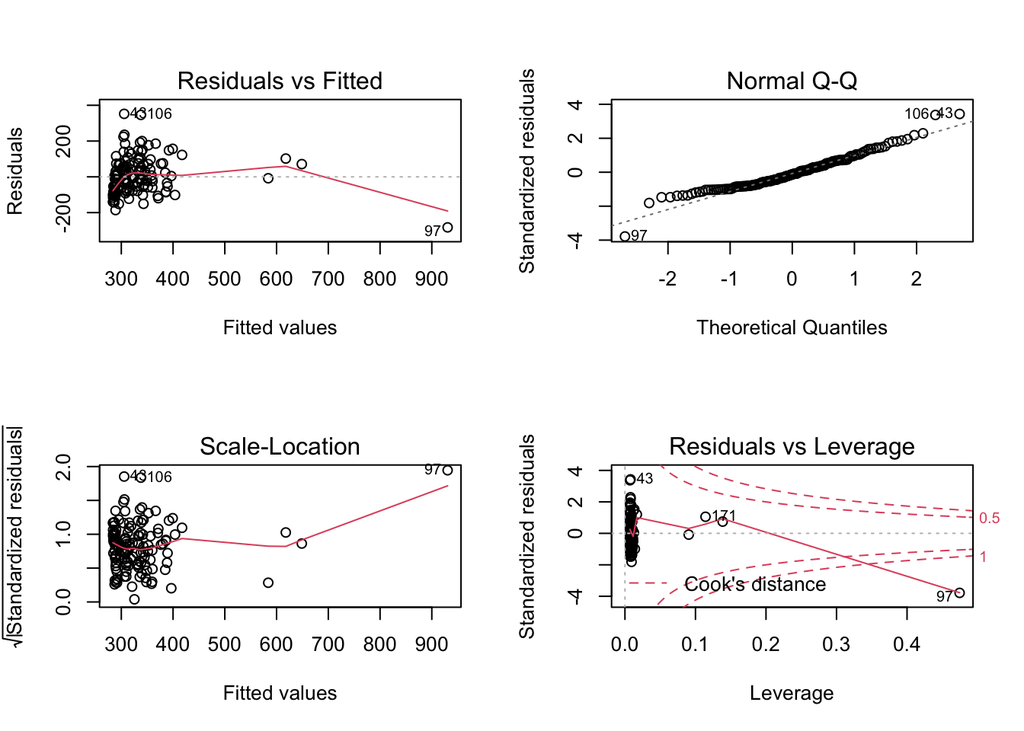

```r
# model 1
par(mfrow = c(2, 2)) # from {car}, so will output in 1 image
plot(lsbm_m1)
```

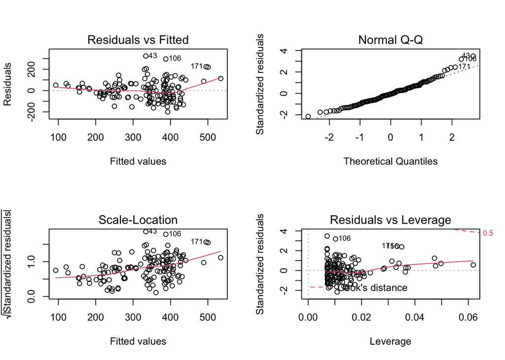

```r
# model 2
par(mfrow = c(2, 2))
plot(lsbm_m2)
```

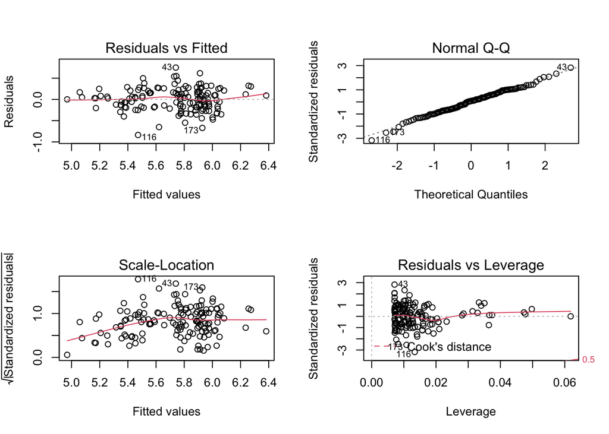

```r
# model 3
par(mfrow = c(2, 2))
plot(lsbm_m3)
```

7. Run a *Shapiro-Wilks test* on residuals for all three models. What do the results suggest? [From module 19.5: “A *Shapiro-Wilk Normality Test* is where a low p value would indicate deviation from normality (technically, a measure of how far the trend line of the residuals deviates from the Q-Q plot line).”]

```r
# H0 = the sample is normally distributed; HA = the sample is not normally distributed. If p > a, then accept H0; If p </= a, then reject H0 in favor of HA.
# model 1
lsbm_s1 <- shapiro.test(lsbm_m1$residuals)
lsbm_s1
```

```
##
##  Shapiro-Wilk normality test
##
## data:  lsbm_m1$residuals
## W = 0.96352, p-value = 0.0008238
```

```r
# model 2
lsbm_s2 <- shapiro.test(lsbm_m2$residuals)
lsbm_s2
```

```
##
##  Shapiro-Wilk normality test
##
## data:  lsbm_m2$residuals
## W = 0.97515, p-value = 0.01131
```

```r
# model 3
lsbm_s3 <- shapiro.test(lsbm_m3$residuals)
lsbm_s3
```

```
##
##  Shapiro-Wilk normality test
##
## data:  lsbm_m3$residuals
## W = 0.99319, p-value = 0.7403
```

**Q from class:** What do the results suggest? For model 3, because p> 0.05, I can accept the null hypothesis of a normal distribution of the residuals of the linear model. For model 1 and 2, the p-value is much less that 0.05, meaning I can accept the alternative hypothesis of the data not being normally distributed.